# xwMOOC 라즈베리파이

RPi 유틸리티

### 학습 목표

> - 콘솔, GUI, 미디어센터 화면을 캡쳐한다.
> - 동영상, 소리, 웹브라우져 설정한다.

[figure not shown]

## 1. 화면 캡쳐

### 1.1. 명령라인 인터페이스 화면 캡쳐

라즈베리 파이 명령라인 인터페이스(CLI)를 쓰게 되면 터미널 콘솔에 찍히는 색깔이 검은색 바탕에 흰색이 아니고, 사용자명/호스트 컴퓨터명/현재 디렉토리/파일과 디렉토리에 시각정보를 입혀서 보기 좋게 표현한다. 이런 화면을 잡아낼 때 사용하는 것이 **fbgrab** 이다.

**fbgrab 설치 및 실행 명령어** `sudo apt-get install fbgrab` 명령어를 넣어 설치하고, `sudo fbgrab screenshot.png` 와 같이 타이핑하면 콘솔화면이 저장된다. `ssh`를 통해 원격으로 접속해서 해당 명령어를 입력한 경우 원격 접속한 터미널 화면이 캡쳐되는 것이 아니라 라즈베리 파이에서 돌고 있는 해당 화면이 직접 캡쳐된다.

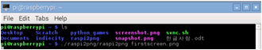

참조: [[라즈베리파이 기초] (6) 콘솔 화면 캡쳐](http://echo.tistory.com/45)

### 1.2. 화면 캡쳐한 것 가져오기

라즈베리 파이 하드웨어에 미디어센터 OSMC를 올린 사례를 살펴보자. OSMC는 오픈일렉(OpenElec)과 달리 sftp, scp 등을 지원한다. 이러한 기능을 통해서 OSMC 에서 캡쳐한 파일을 가져다가 편집등 작업을 할 수 있다.

1. 라즈베리 파이 OSMC 미디어 센터 화면 캡쳐하는 방법
   - 단축키 `Ctrl + S`를 눌러 설정한다. (주의: 처음 `Ctrl+S`를 누르면 캡쳐한 파일을 저장할 디렉토리 지정하라고 안내가 나옴)
   - raspi2png 프로그램으로 화면 캡쳐함.
2. 라즈베리 파이 OSMC 캡쳐된 파일 로컬 컴퓨터로 복사해서 가져오는 방법
   - [filezilla](https://filezilla-project.org/), [Winscp](http://winscp.net/eng/docs/lang:ko) 등등 [파일전송프로토콜(FTP)](https://ko.wikipedia.org/wiki/파일_전송_프로토콜) 프로그램을 사용해서 가져온다.
   - 명령라인 인터페이스 `sftp`를 통해 원격 컴퓨터에 접속해서 `get` 명령어로 해당 파일을 가져온다.
   - `scp` 명령어를 통해서 원격 컴퓨터(OSMC 라즈베리 파이)에서 복사해서 가져온다. -. 윈도우 환경에서 **bash** 명령어를 사용하기 위해서는 [Git Bash](https://msysgit.github.io/)를 설치해서 가져온다.
     - git 대몬을 다음 명령어로 띄운다. `git daemon --base-path=. --export-all`
     - 새로운 창을 열고 `scp -r osmc@192.168.103.130:~/snapshot.png winsnapshot.png` 명령어처럼 192.168.103.130 호스트에 `osmc` 사용자로 로그인해서 `~/` 디렉토리에 `snapshot.png` 파일을 복사해서 로컬 컴퓨터에 `winsnapshot.png` 이름으로 가져온다.

[figure not shown]

`raspi2png` 프로그램의 실행파일은 `git clone` 명령어로 복제한 디렉토리 *raspi2png* **아래 raspi2png** 이다. 프로그램이 설치된 디렉토리로 들어가서 `./raspi2png` 명령어를 실행하면 snapshot.png 파일이 자동 생성된다.

[figure not shown]

```r
osmc@osmc:~/raspi2png$ sudo passwd root
Enter new UNIX password:
Retype new UNIX password:
passwd: password updated successfully
root@osmc:/home/osmc# git clone https://github.com/AndrewFromMelbourne/raspi2png.git
root@osmc:/home/osmc# cd raspi2png/
root@osmc:/home/osmc/raspi2png# ls
LICENSE  Makefile  README.md  raspi2png  raspi2png.c
root@osmc:/home/osmc/raspi2png# ./raspi2png
root@osmc:/home/osmc/raspi2png# ls
LICENSE  Makefile  README.md  raspi2png  raspi2png.c  snapshot.png
```

참조: [[라즈베리파이 기초] (7) 라즈베리파이 스크린샷 끝!!](http://echo.tistory.com/48)